# Exploration

## Source of Data

- This dataset was compiled by Godwin Abah through the Central Bank of Nigeria. It contains the raw data for all importation of goods into Nigeria from January 2019 to December 2019. The dataset includes details on the type of goods imported, the importer, the suppliers details, the commercial bank through which the trade was facilitated and the description, size and cost of each goods. sources(https://www.kaggle.com/datasets/godwinabah/2019-nigerian-import-data?select=2019+NIGERIAN+IMPORT+DATA.xlsx)

## Objective of Data exploration

- To explore Dataset and give insight base on the exchange rate, mode of payment by importers, Banks used for transactions by importers

```python
import pandas as pd
import numpy as np
import seaborn as sns
import matplotlib.pyplot as plt
```

```python
df = pd.read_csv("Nigerian_import_data_cleaned.csv")
df.head(10)
```

|  | Unnamed: 0 | S/N | BANK_CODE | BNK_NAM | APP_YEAR | AUTHORIZED_DEALER_DATE | EXC_RATE | CURRENCY | FOB_VAL | FREIGHT_VAL | CFR | USD_EQUIV | PAYMENT_MODE | APPLICANT_RCN_CODE | APPLICANT_NAME | EXPORTER | ITEM | FOB_Value_Naira |
| --- | --- | --- | --- | --- | --- | --- | --- | --- | --- | --- | --- | --- | --- | --- | --- | --- | --- | --- |
| 0 | 0 | 9577 | 214 | First City Monument Bank PLC | 2019 | 2019-01-31 | 0.534 | CFA | 69840000.00 | 745000.0 | 70585000.00 | 119337.353650 | Bills for Collection | 16298228-0001 | SUNSTEEL INDUSTRIES LIMITED | ENSCO SERVICES LIMITED | RIG SPARES | 3.729456e+07 |
| 1 | 1 | 6756 | 44 | Access Bank PLC | 2019 | 2019-01-23 | 311.738 | CHF | 6034.44 | 1260.0 | 7294.44 | 7569.002722 | Bills for Collection | 00389604-0001 | NESTLE NIG. PLC | Solventek Trading DMCC | 100 Metric Tons of Toluene Diisocyanate - TDI ... | 1.881164e+06 |
| 2 | 2 | 17380 | 23 | Citibank Nigeria Limited | 2019 | 2019-02-27 | 308.819 | CHF | 4525.83 | 945.0 | 5470.83 | 5676.752041 | Bills for Collection | 00389604-0001 | NESTLE NIG. PLC | JAT OFFSHORE S.A.L | AGRICULTURAL INSECTICIDES | 1.397662e+06 |
| 3 | 3 | 18398 | 23 | Citibank Nigeria Limited | 2019 | 2019-03-01 | 308.819 | CHF | 585990.00 | 10221.0 | 596211.00 | 618652.382040 | Bills for Collection | 00389604-0001 | NESTLE NIG. PLC | TEREOS STARCH&SWEETENERS BELGIUM N.V | MAIZE STARCH | 1.809648e+08 |
| 4 | 4 | 4799 | 23 | Citibank Nigeria Limited | 2019 | 2019-04-12 | 308.214 | CHF | 66118.00 | 1125.0 | 67243.00 | 69774.026520 | Bills for Collection | 00389604-0001 | NESTLE NIG. PLC | NESTLE SUISSE S.A. | NAN 3 BL DHA Probio LEB027A-2 12x400g | 2.037849e+07 |
| 5 | 5 | 12441 | 23 | Citibank Nigeria Limited | 2019 | 2019-05-07 | 308.214 | CHF | 4492.71 | 945.0 | 5437.71 | 5642.385404 | Bills for Collection | 00389604-0001 | NESTLE NIG. PLC | NESTLE SUISSE S.A. | PROBIOTIC PREBLEND PP017 Box 4x5kg | 1.384716e+06 |
| 6 | 6 | 16945 | 23 | Citibank Nigeria Limited | 2019 | 2019-05-17 | 301.079 | CHF | 2898.00 | 819.0 | 3717.00 | 3856.907880 | Bills for Collection | 00081241-0001 | PROCTER & GAMBLE NIG. LTD. | GIVAUDAN MEA FZE | FRESHGUARD 78CD/7 MOD D (RAW MATERIAL FOR PROD... | 8.725269e+05 |
| 7 | 7 | 26729 | 23 | Citibank Nigeria Limited | 2019 | 2019-06-20 | 324.281 | CHF | 4516.02 | 945.0 | 5461.02 | 5666.572793 | Bills for Collection | 00389604-0001 | NESTLE NIG. PLC | NESTLE SUISSE S.A | PROBIOTIC PREBLEND | 1.464459e+06 |
| 8 | 8 | 37811 | 23 | Citibank Nigeria Limited | 2019 | 2019-07-23 | 324.281 | CHF | 4516.02 | 945.0 | 5461.02 | 5666.572793 | Bills for Collection | 00389604-0001 | NESTLE NIG. PLC | NESTLE SUISSE S.A | PROBIOTIC PREBLEND | 1.464459e+06 |
| 9 | 9 | 58624 | 23 | Citibank Nigeria Limited | 2019 | 2019-09-02 | 324.281 | CHF | 4489.38 | 945.0 | 5434.38 | 5638.930063 | Bills for Collection | 00389604-0001 | NESTLE NIG. PLC | NESTLE SUISSE S.A | PROBIOTIC PREBLEND | 1.455821e+06 |

- What features in the dataset do you think will help support your investigation into your feature(s) of interest? FOB_VAL, FOB Value Naira and EXC_RATE

```python
df.ITEM.value_counts().sum()
```

```
62237
```

```python
df.isna().sum()
```

```
Unnamed: 0                0
S/N                       0
BANK_CODE                 0
BNK_NAM                   0
APP_YEAR                  0
AUTHORIZED_DEALER_DATE    0
EXC_RATE                  0
CURRENCY                  0
FOB_VAL                   0
FREIGHT_VAL               0
CFR                       0
USD_EQUIV                 0
PAYMENT_MODE              0
APPLICANT_RCN_CODE        0
APPLICANT_NAME            0
EXPORTER                  0
ITEM                      1
FOB_Value_Naira           0
dtype: int64
```

```python
df.fillna(0)
```

|  | Unnamed: 0 | S/N | BANK_CODE | BNK_NAM | APP_YEAR | AUTHORIZED_DEALER_DATE | EXC_RATE | CURRENCY | FOB_VAL | FREIGHT_VAL | CFR | USD_EQUIV | PAYMENT_MODE | APPLICANT_RCN_CODE | APPLICANT_NAME | EXPORTER | ITEM | FOB_Value_Naira |
| --- | --- | --- | --- | --- | --- | --- | --- | --- | --- | --- | --- | --- | --- | --- | --- | --- | --- | --- |
| 0 | 0 | 9577 | 214 | First City Monument Bank PLC | 2019 | 2019-01-31 | 0.5340 | CFA | 69840000.00 | 745000.00 | 70585000.00 | 119337.353650 | Bills for Collection | 16298228-0001 | SUNSTEEL INDUSTRIES LIMITED | ENSCO SERVICES LIMITED | RIG SPARES | 3.729456e+07 |
| 1 | 1 | 6756 | 44 | Access Bank PLC | 2019 | 2019-01-23 | 311.7380 | CHF | 6034.44 | 1260.00 | 7294.44 | 7569.002722 | Bills for Collection | 00389604-0001 | NESTLE NIG. PLC | Solventek Trading DMCC | 100 Metric Tons of Toluene Diisocyanate - TDI ... | 1.881164e+06 |
| 2 | 2 | 17380 | 23 | Citibank Nigeria Limited | 2019 | 2019-02-27 | 308.8190 | CHF | 4525.83 | 945.00 | 5470.83 | 5676.752041 | Bills for Collection | 00389604-0001 | NESTLE NIG. PLC | JAT OFFSHORE S.A.L | AGRICULTURAL INSECTICIDES | 1.397662e+06 |
| 3 | 3 | 18398 | 23 | Citibank Nigeria Limited | 2019 | 2019-03-01 | 308.8190 | CHF | 585990.00 | 10221.00 | 596211.00 | 618652.382040 | Bills for Collection | 00389604-0001 | NESTLE NIG. PLC | TEREOS STARCH&SWEETENERS BELGIUM N.V | MAIZE STARCH | 1.809648e+08 |
| 4 | 4 | 4799 | 23 | Citibank Nigeria Limited | 2019 | 2019-04-12 | 308.2140 | CHF | 66118.00 | 1125.00 | 67243.00 | 69774.026520 | Bills for Collection | 00389604-0001 | NESTLE NIG. PLC | NESTLE SUISSE S.A. | NAN 3 BL DHA Probio LEB027A-2 12x400g | 2.037849e+07 |
| ... | ... | ... | ... | ... | ... | ... | ... | ... | ... | ... | ... | ... | ... | ... | ... | ... | ... | ... |
| 62233 | 62233 | 5761 | 35 | Wema Bank PLC | 2019 | 2019-04-16 | 21.9911 | ZAR | 257778.66 | 55000.00 | 312778.66 | 20784.454736 | Letters of Credit | 10173169-0001 | DE-OBABOB INVESTMENT LTD. CALABAR | ZHAUNS BUSINESS OPPORTUNITIES (PTY) LTD AND EN... | TOILET ROLL MACHINE MODEL 1.3 AND INDUSTRIAL B... | 5.668836e+06 |
| 62234 | 62234 | 16235 | 57 | Zenith Bank PLC | 2019 | 2019-05-16 | 21.4110 | ZAR | 536002.50 | 41000.00 | 577002.50 | 38342.393127 | Letters of Credit | 01057508-0001 | LAFARGE AFRICA PLC | Martin Bulk Handling Solutions (Pty) Ltd | XHD REPLACEMENT BLADE ORANGE MAXIMIZER 13IN (3... | 1.147635e+07 |
| 62235 | 62235 | 20781 | 57 | Zenith Bank PLC | 2019 | 2019-06-03 | 21.6970 | ZAR | 527684.00 | 48376.00 | 576060.00 | 38279.763060 | Letters of Credit | 04059106-0001 | DANGOTE CEMENT PLC | ERIEZ MAGNETICS SA PTY LTD | METAL DETECTOR | 1.144916e+07 |
| 62236 | 62236 | 31796 | 57 | Zenith Bank PLC | 2019 | 2019-07-05 | 22.1540 | ZAR | 93791.80 | 6228.67 | 100020.47 | 6646.460252 | Letters of Credit | 01057508-0001 | LAFARGE AFRICA PLC | MMD Mineral Sizing (Africa) (Pty) Ltd. | Bearing Assembly | 2.077864e+06 |
| 62237 | 62237 | 37455 | 57 | Zenith Bank PLC | 2019 | 2019-07-22 | 21.8701 | ZAR | 345929.20 | 68540.80 | 414470.00 | 27541.945970 | Letters of Credit | 01485395-0001 | HEIDELBERG NIGERIA LIMITED | ECO PRESSROOM PRODUCTS (PTY) LTD | CHEMICALS FOR THE PRINTING INDUSTRY | 7.565506e+06 |

62238 rows × 18 columns

```python
df.info()
```

```
<class 'pandas.core.frame.DataFrame'>
RangeIndex: 62238 entries, 0 to 62237
Data columns (total 18 columns):
 #   Column                  Non-Null Count  Dtype
---  ------                  --------------  -----
 0   Unnamed: 0              62238 non-null  int64
 1   S/N                     62238 non-null  int64
 2   BANK_CODE               62238 non-null  int64
 3   BNK_NAM                 62238 non-null  object
 4   APP_YEAR                62238 non-null  int64
 5   AUTHORIZED_DEALER_DATE  62238 non-null  object
 6   EXC_RATE                62238 non-null  float64
 7   CURRENCY                62238 non-null  object
 8   FOB_VAL                 62238 non-null  float64
 9   FREIGHT_VAL             62238 non-null  float64
 10  CFR                     62238 non-null  float64
 11  USD_EQUIV               62238 non-null  float64
 12  PAYMENT_MODE            62238 non-null  object
 13  APPLICANT_RCN_CODE      62238 non-null  object
 14  APPLICANT_NAME          62238 non-null  object
 15  EXPORTER                62238 non-null  object
 16  ITEM                    62237 non-null  object
 17  FOB_Value_Naira         62238 non-null  float64
dtypes: float64(6), int64(4), object(8)
memory usage: 8.5+ MB
```

```python
df.columns
```

```
Index(['Unnamed: 0', 'S/N', 'BANK_CODE', 'BNK_NAM', 'APP_YEAR',
       'AUTHORIZED_DEALER_DATE', 'EXC_RATE', 'CURRENCY', 'FOB_VAL',
       'FREIGHT_VAL', 'CFR', 'USD_EQUIV', 'PAYMENT_MODE', 'APPLICANT_RCN_CODE',
       'APPLICANT_NAME', 'EXPORTER', 'ITEM', 'FOB_Value_Naira'],
      dtype='object')
```

## Univariant Analysis

```python
df.describe()
```

|  | Unnamed: 0 | S/N | BANK_CODE | APP_YEAR | EXC_RATE | FOB_VAL | FREIGHT_VAL | CFR | USD_EQUIV | FOB_Value_Naira |
| --- | --- | --- | --- | --- | --- | --- | --- | --- | --- | --- |
| count | 62238.000000 | 62238.000000 | 62238.000000 | 62238.0 | 62238.000000 | 6.223800e+04 | 6.223800e+04 | 6.223800e+04 | 6.223800e+04 | 6.223800e+04 |
| mean | 31118.500000 | 36081.851232 | 78.550757 | 2019.0 | 317.532525 | 4.261340e+05 | 3.840211e+04 | 4.645362e+05 | 3.853367e+05 | 1.114438e+08 |
| std | 17966.707364 | 25366.821444 | 74.796830 | 0.0 | 37.431839 | 2.506017e+06 | 2.263975e+05 | 2.664023e+06 | 1.818331e+06 | 5.454166e+08 |
| min | 0.000000 | 1.000000 | 11.000000 | 2019.0 | 0.534000 | 0.000000e+00 | 0.000000e+00 | 0.000000e+00 | 0.000000e+00 | 0.000000e+00 |
| 25% | 15559.250000 | 14448.250000 | 35.000000 | 2019.0 | 306.950000 | 3.472907e+04 | 2.700000e+03 | 3.900050e+04 | 3.931820e+04 | 1.102772e+07 |
| 50% | 31118.500000 | 28869.000000 | 57.000000 | 2019.0 | 326.000000 | 8.868400e+04 | 6.000000e+03 | 9.702000e+04 | 9.700000e+04 | 2.798929e+07 |
| 75% | 46677.750000 | 57668.750000 | 68.000000 | 2019.0 | 326.000000 | 2.324000e+05 | 1.819125e+04 | 2.520000e+05 | 2.475000e+05 | 7.180290e+07 |
| max | 62237.000000 | 86390.000000 | 561.000000 | 2019.0 | 430.000000 | 2.180500e+08 | 1.664500e+07 | 2.263500e+08 | 2.263500e+08 | 6.670149e+10 |

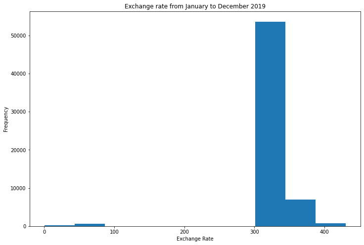

```python
plt.figure(figsize=(12, 8))
plt.hist(df.EXC_RATE);
plt.title("Exchange rate from January to December 2019")
plt.xlabel("Exchange Rate")
plt.ylabel("Frequency");
```

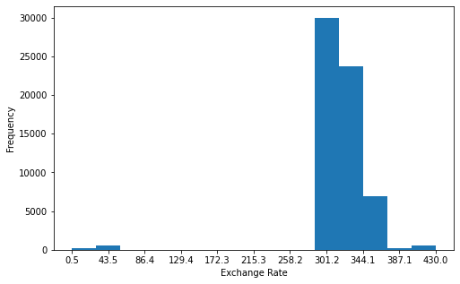

```python
count, bin_edges = np.histogram(df['EXC_RATE'], 10)
df['EXC_RATE'].plot(kind='hist', figsize=(8,5), xticks=bin_edges, bins=15);
plt.xlabel('Exchange Rate')
plt.show()
```

- Due to the fact that the viz still not showing much, lets create bins from the data point min and max
- **Rubric** Tips Visualizations should depict the data appropriately so that the plots are easily interpretable. You should choose an appropriate plot type, data encodings, and formatting as needed. The formatting may include setting/adding the title, labels, legend, and comments. Also, do not overplot or incorrectly plot ordinal data.

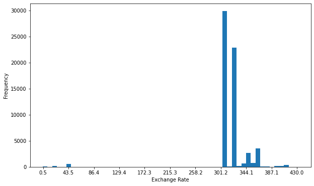

```python
binsize = 8
bins = np.arange(0, df['EXC_RATE'].max()+binsize, binsize)
count, bin_edges = np.histogram(df['EXC_RATE'])
df['EXC_RATE'].plot(kind='hist', figsize=(10,6), xticks=bin_edges,
                   bins=bins);
plt.xlabel('Exchange Rate')
plt.show()
```

- From the visualization above we can now confirm that exchange rate is skwed to the left due to the fact that we have being able to plot three different plot and we have same shape of graph

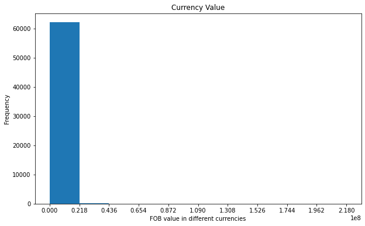

```python
# Plotting the histogram for fob value for different currencies
plt.figure(figsize=(10,6))
# plt.subplot(1, 2, 1)
# binsize = 1000000
count, bin_edges = np.histogram(df['FOB_VAL'])
df['FOB_VAL'].plot(kind='hist', xticks=bin_edges,
                   bins=10);
# plt.xscale('log')
plt.xlabel('FOB value in different currencies')
plt.title("Currency Value");
```

- The graph above shows that the frequency of free on board is skwed to the right, but there is the need to verify this because there seem to be high spread between the data points. So in this case am going to use a subplot to plot with and without log graph to show a clear difference and give a clear visualization of frequency.

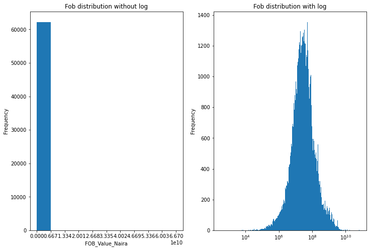

```python
plt.figure(figsize=(12,8))
plt.subplot(1, 2, 1)
count_1, bin_edges_1 = np.histogram(df['FOB_Value_Naira']) # the numpy histogram function is used to get the bin edges and count for each bin intervals
df['FOB_Value_Naira'].plot(kind='hist', xticks=bin_edges_1);
plt.xlabel('FOB_Value_Naira')
plt.title("Fob distribution without log")
plt.subplot(1, 2, 2)
log_binsize = 0.030
bins = 10 ** np.arange(2.5, np.log10(df['FOB_Value_Naira'].max())+log_binsize, log_binsize) # logging the max data point and adding the log binsize
# count, bin_edges = np.histogram(df['FOB_Value_Naira'])
df['FOB_Value_Naira'].plot(kind='hist',
                   bins=bins)
plt.title("Fob distribution with log");
plt.xscale('log')
plt.show()
```

```python
def chart(dataframe, X, rot=0):
    sns.countplot(data=dataframe, x=X)
    sns.set_style('whitegrid')
    plt.xticks(rotation=rot)
```

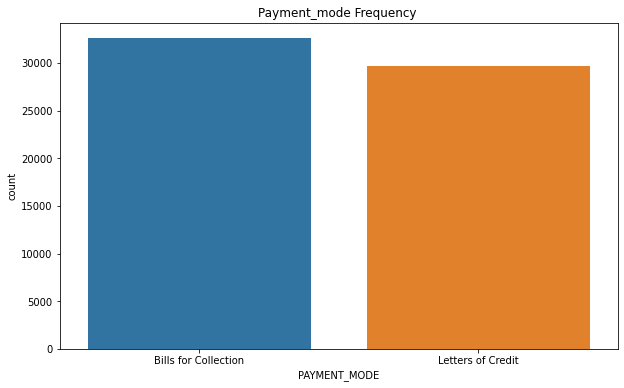

```python
plt.figure(figsize=(10,6))
chart(df, "PAYMENT_MODE")
plt.title("Payment_mode Frequency ");
```

- The visualization above shows that importers tend to use more of Bill of colection in 2019 compare to Letter of Credit

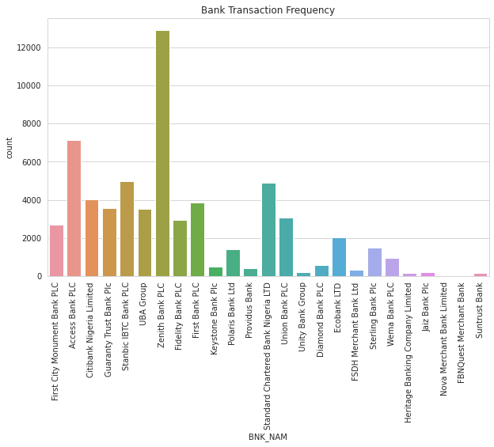

```python
plt.figure(figsize=(10,6))
chart(df, "BNK_NAM", 90)
plt.title("Bank Transaction Frequency");
```

- The visualization above shows that Zenith bank is the most predomiant bank used in import transaction for 2019 with over 12000 transactions.

```python
bank_payment_mode = df.loc[df.PAYMENT_MODE == "Bills for Collection"]
```

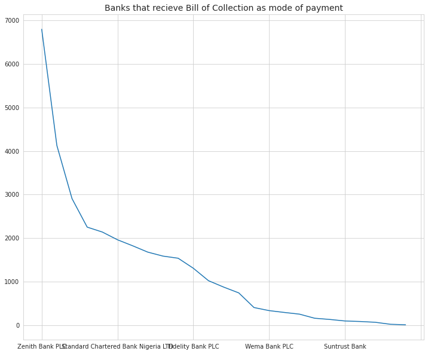

```python
plt.figure(figsize=(12, 10))
bank_payment_mode.BNK_NAM.value_counts().plot()
plt.title("Banks that recieve Bill of Collection as mode of payment", fontsize = 14);
```

```python
bank_payment_mode1 = df.loc[df.PAYMENT_MODE == "Letters of Credit"]
```

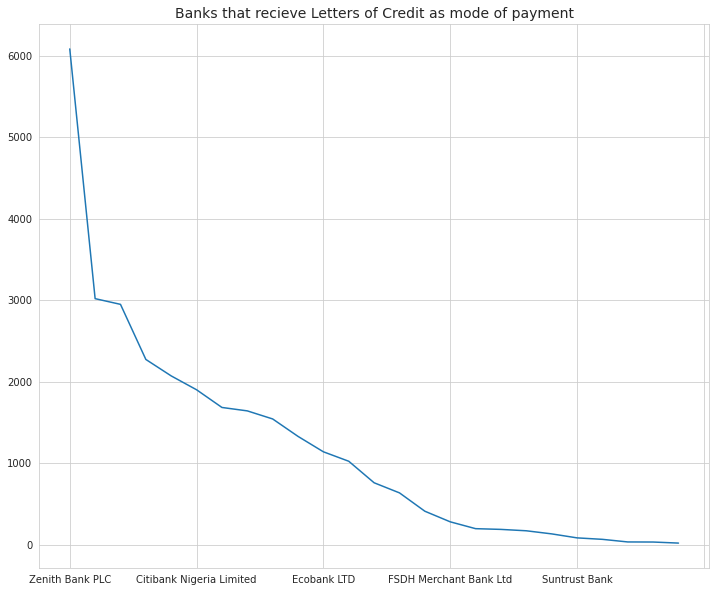

```python
plt.figure(figsize=(12, 10))
bank_payment_mode1.BNK_NAM.value_counts().plot()
plt.title("Banks that recieve Letters of Credit as mode of payment", fontsize = 14);
```

- From the graph above it shows that zenith bank is the most used bank for letter of credits transactions with over 6000 transaction for 2019

#### Of the features you investigated, were there any unusual distributions? Did you perform any operations on the data to tidy, adjust, or change the form of the data? If so, why did you do this?

- In other to discover banks that where use for transaction that involve bill of collection and letter of credit during the period, there is a need to filter out the different means of payment which after we dicovered that banks that where mostly used for transaction of this nature is zenith bank.

## Bivariate Exploration

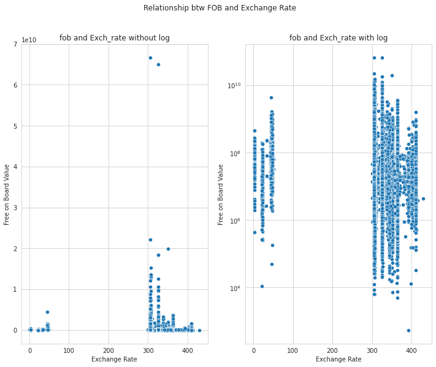

```python
plt.figure(figsize=(12,9))
plt.subplot(1, 2, 1)
sns.scatterplot(x= "EXC_RATE", y='FOB_Value_Naira', data=df);
plt.xlabel('Exchange Rate')
plt.ylabel('Free on Board Value')
plt.title("fob and Exch_rate without log")
plt.subplot(1, 2, 2)
sns.scatterplot(x= "EXC_RATE", y='FOB_Value_Naira', data=df);
plt.xlabel('Exchange Rate')
plt.yscale('log')
plt.ylabel('Free on Board Value')
plt.title("fob and Exch_rate with log")
plt.suptitle("Relationship btw FOB and Exchange Rate");
```

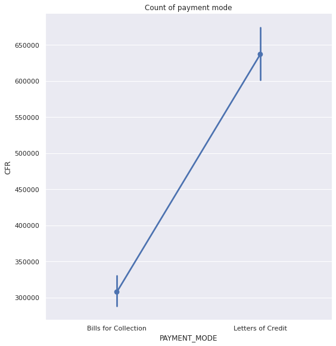

```python
sns.set_theme(style="darkgrid")
g = sns.catplot(x='PAYMENT_MODE', y='CFR', data=df,
kind='point', height=8)
plt.title("Count of payment mode");
```

- The graph above show that the average mode of payment for cost of freigt using bills for collection as a mode of payment is between 300000 and 350000 and the average cost of freight for letter of Credit is between 600000 and 650000 a significant difference right? which goes to tell us reason why importer tend to use more of Bills of Collection compare to Letters of Credits.

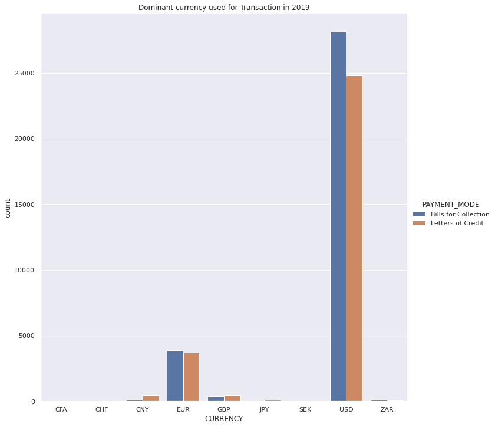

```python
sns.catplot(x='CURRENCY', data=df, hue='PAYMENT_MODE', kind='count', height=10);
plt.title("Dominant currency used for Transaction in 2019");
```

- From the graph above we see that the most predominant currency used for transaction in Nigeria for both Bill of Collection and Letters of Credit is the Dollar.

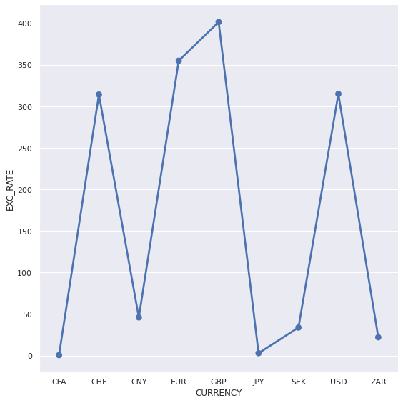

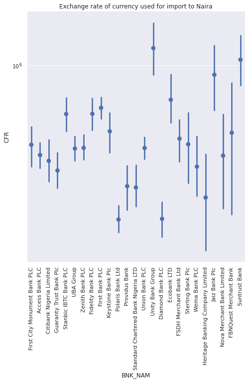

```python
sns.catplot(data=df, x='CURRENCY', y='EXC_RATE', kind='point', height=8)
sns.catplot(x='BNK_NAM', y="CFR", data=df, kind='point', join=False, height=8)
plt.xticks(rotation=90)
plt.title("Exchange rate of currency used for import to Naira")
plt.yscale('log');
```

```python
currency = df.groupby('CURRENCY', axis=0).sum()
```

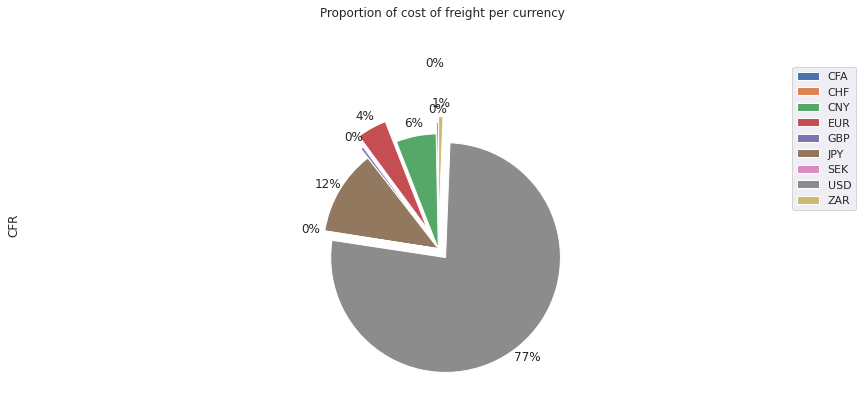

```python
colors_list = ['red', 'yellowgreen', 'lightcoral', 'lightskyblue', 'lightgreen', 'pink', 'beige', 'aqua', 'cornflowerblue']
explode_list = [0.1, 0.5, 0, 0.2, 0.1, 0, 0, 0.1, 0.15] # ratio for each currency with which to offset each wedge.

currency.CFR.plot(kind='pie',
                            figsize=(15, 6),
                            autopct='%1.0f%%',
                            startangle=90,
                            labels=None,         # turn off labels on pie chart
                            pctdistance=1.12,    # the ratio between the center of each pie slice and the start of the text generated by autopct
                            explode=explode_list # 'explode' lowest 3 currencies
                            )

# scale the title up by 12% to match pctdistance
plt.title('Proportion of cost of freight per currency', y=1.12)

plt.axis('equal')

# add legend
plt.legend(labels=currency.index, loc='upper right');
```

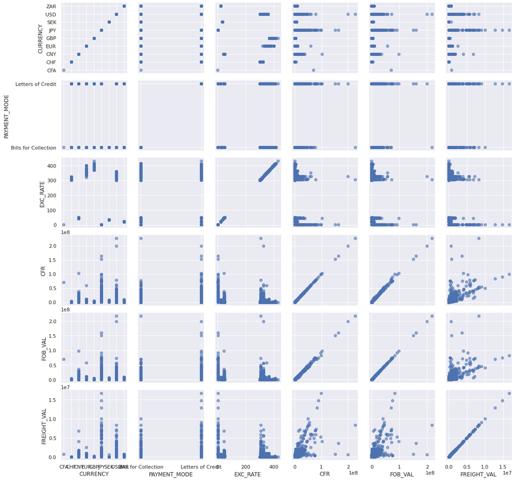

```python
g = sns.PairGrid(df, vars=['CURRENCY', 'PAYMENT_MODE', 'EXC_RATE', 'CFR', 'FOB_VAL', 'FREIGHT_VAL'], palette='RbBu_r')
g.map(plt.scatter, alpha=0.6);
```

- The data plot shows the relationships across different variables selected, this just help in seeing the correlation across the selected variables.

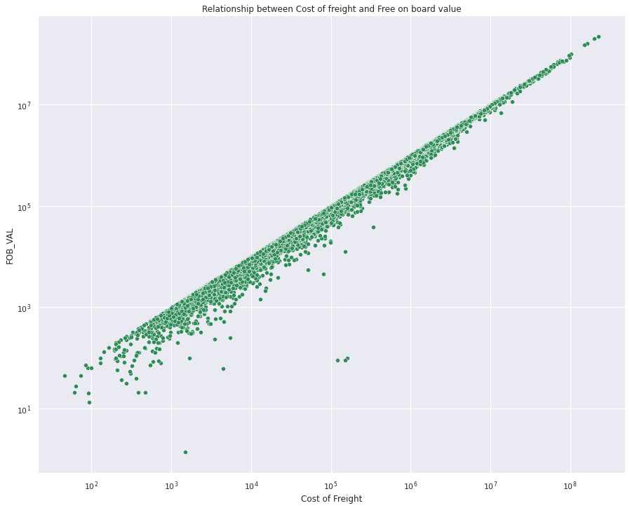

```python
plt.figure(figsize=(15,12))
sns.scatterplot(x='CFR', y='FOB_VAL', data=df, color='seagreen')
plt.xscale('log')
plt.yscale('log')
plt.xlabel('Cost of Freight')
plt.title('Relationship between Cost of freight and Free on board value');
```

- The plot shows a strong positive correlation between cost of freight and free on board that is to say if there is an increase in cost of freight there will also be increase in fob as well meaning both variable affect each other positively

#### Talk about some of the relationships you observed in this part of the investigation. How did the feature(s) of interest vary with other features in the dataset?

- From the visualization, it is clear that little variables has relationship with each other.

#### Did you observe any interesting relationships between the other features (not the main feature(s) of interest)?

```python
df_new = df.loc[:, ['FREIGHT_VAL', 'CFR', 'EXC_RATE', 'FOB_VAL', 'CURRENCY']] # creating a new subset of the date
df_new.head()
```

|  | FREIGHT_VAL | CFR | EXC_RATE | FOB_VAL | CURRENCY |
| --- | --- | --- | --- | --- | --- |
| 0 | 745000.0 | 70585000.00 | 0.534 | 69840000.00 | CFA |
| 1 | 1260.0 | 7294.44 | 311.738 | 6034.44 | CHF |
| 2 | 945.0 | 5470.83 | 308.819 | 4525.83 | CHF |
| 3 | 10221.0 | 596211.00 | 308.819 | 585990.00 | CHF |
| 4 | 1125.0 | 67243.00 | 308.214 | 66118.00 | CHF |

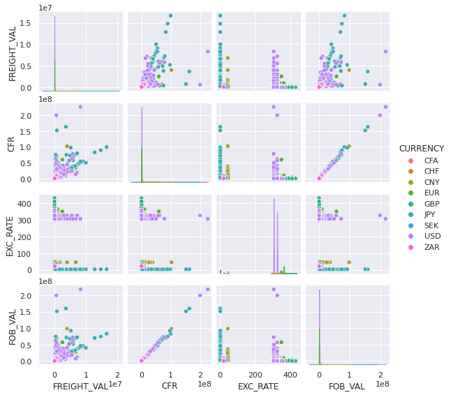

```python
sns.set_style('darkgrid')
sns.set_palette('Accent')
sns.pairplot(df_new, hue='CURRENCY', height=2.0);
```

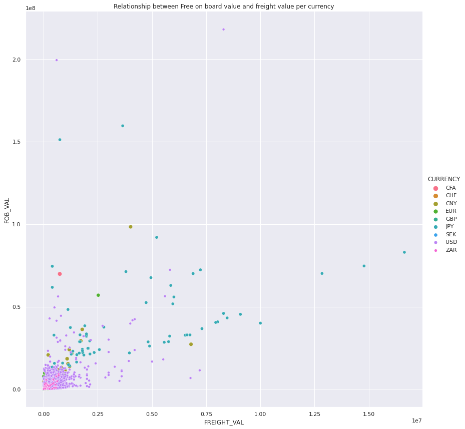

```python
plt.figure(figsize=(10, 6))
sns.relplot(x='FREIGHT_VAL', y='FOB_VAL', data=df,
           kind='scatter', hue='CURRENCY', size='CURRENCY', height=12)
plt.title('Relationship between Free on board value and freight value per currency');
```

- The above scatter plot visualization shows the relationship between FOB and FREIGHT_val on currency. However, the plot doesnt show a clear relationship because the data points is clustered within a certain region.

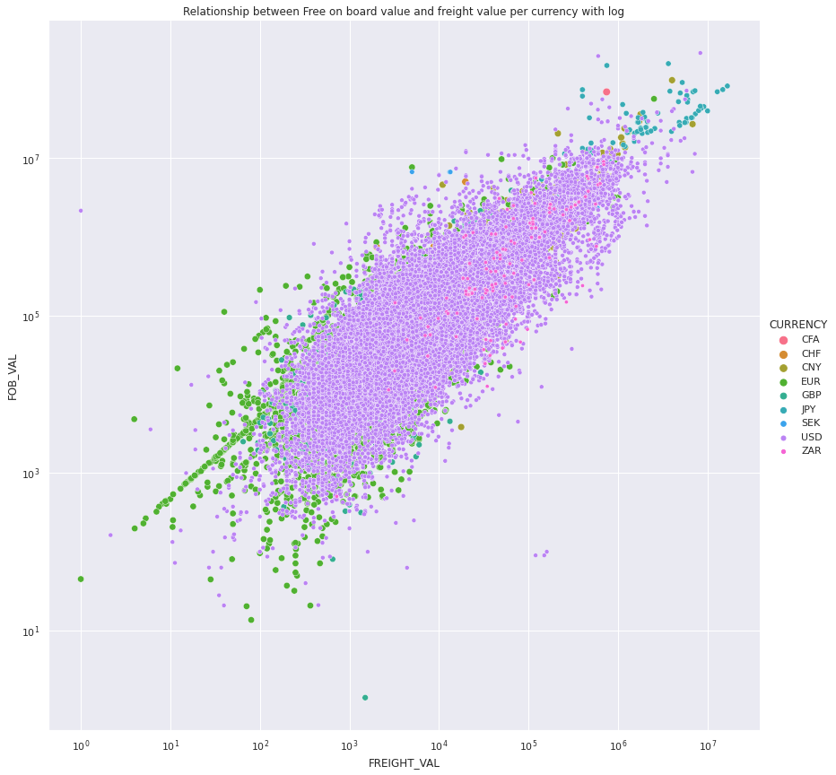

```python
plt.figure(figsize=(10,6))
sns.relplot(x='FREIGHT_VAL', y='FOB_VAL', data=df,
           kind='scatter', hue='CURRENCY', size='CURRENCY', height=12);
plt.xscale('log')
plt.yscale('log')
plt.title('Relationship between Free on board value and freight value per currency with log');
```

- From the above visualization it shows that there is high correlation between FOB and FREIGHT_val, and the most dominant currency used when it comes to transaction in freight and free on board is basically dollars, then euros while others are sometimes rarely used for such transaction.

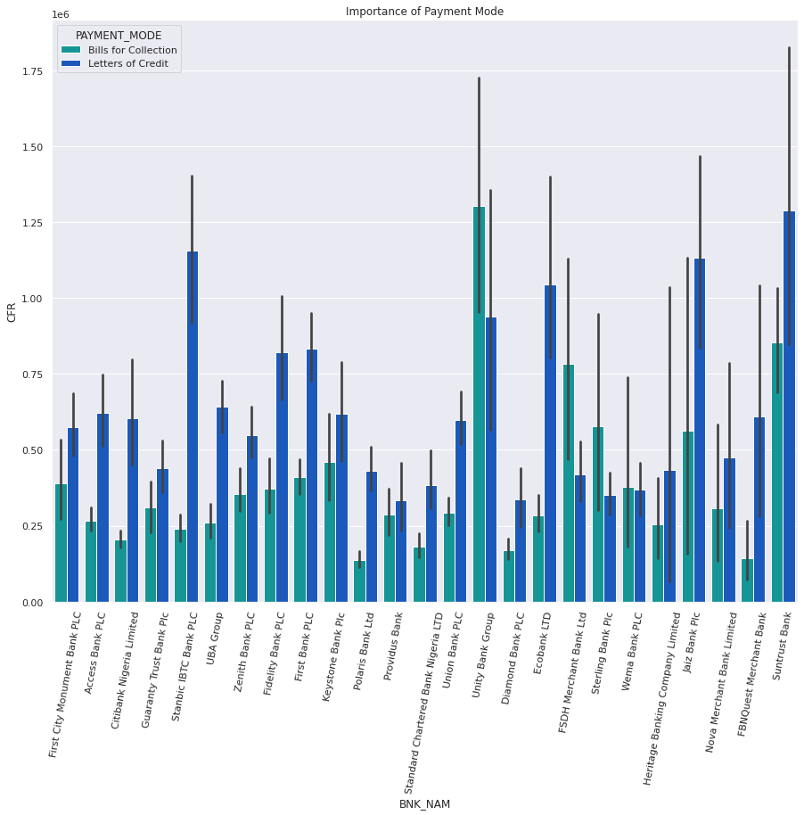

```python
plt.figure(figsize=(15, 12))
sns.set_style(style='darkgrid')
sns.barplot(data=df, x='BNK_NAM', y='CFR', hue="PAYMENT_MODE", palette='winter_r');
plt.xticks(rotation=80)
plt.title("Importance of Payment Mode");
```

- From the univariant plot where the distribution of payment mode shows that importers used bills of collection in transaction compare to letter of credit, there is a need to see the importance of both mode of payment despite the fact that importers slightly prefer bills for collection than the other. And this help broaden our insight that bills for collection might be more common but letters are highly used for for high cost of freight among banks.

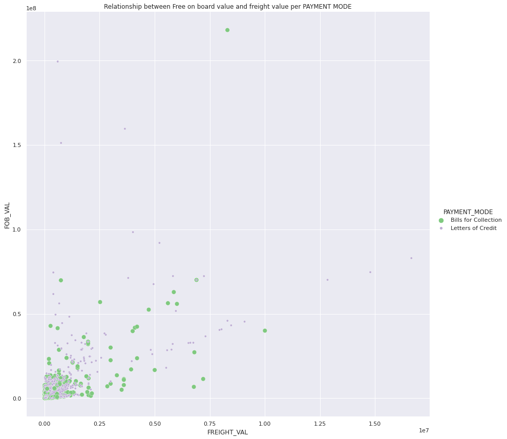

```python
plt.figure(figsize=(10,6))
sns.relplot(x='FREIGHT_VAL', y='FOB_VAL', data=df,
           kind='scatter', hue='PAYMENT_MODE', size='PAYMENT_MODE', height=12);
plt.title('Relationship between Free on board value and freight value per PAYMENT MODE');
```

- From the visualization the relationship between Freight and FOB_VAl is still blur and there is a need to visualized clearly for proper analysis.

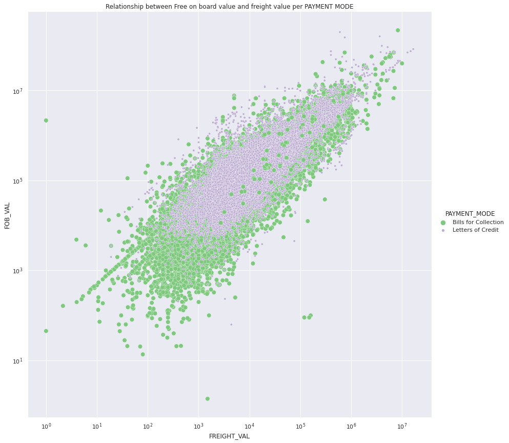

```python
plt.figure(figsize=(10,6))
sns.relplot(x='FREIGHT_VAL', y='FOB_VAL', data=df,
           kind='scatter', hue='PAYMENT_MODE', size='PAYMENT_MODE', height=12);
plt.xscale('log')
plt.yscale('log')
plt.title('Relationship between Free on board value and freight value per PAYMENT MODE');
```

- After logging the x and y scale this clearly shows a positive relationship between the freight value and fob value

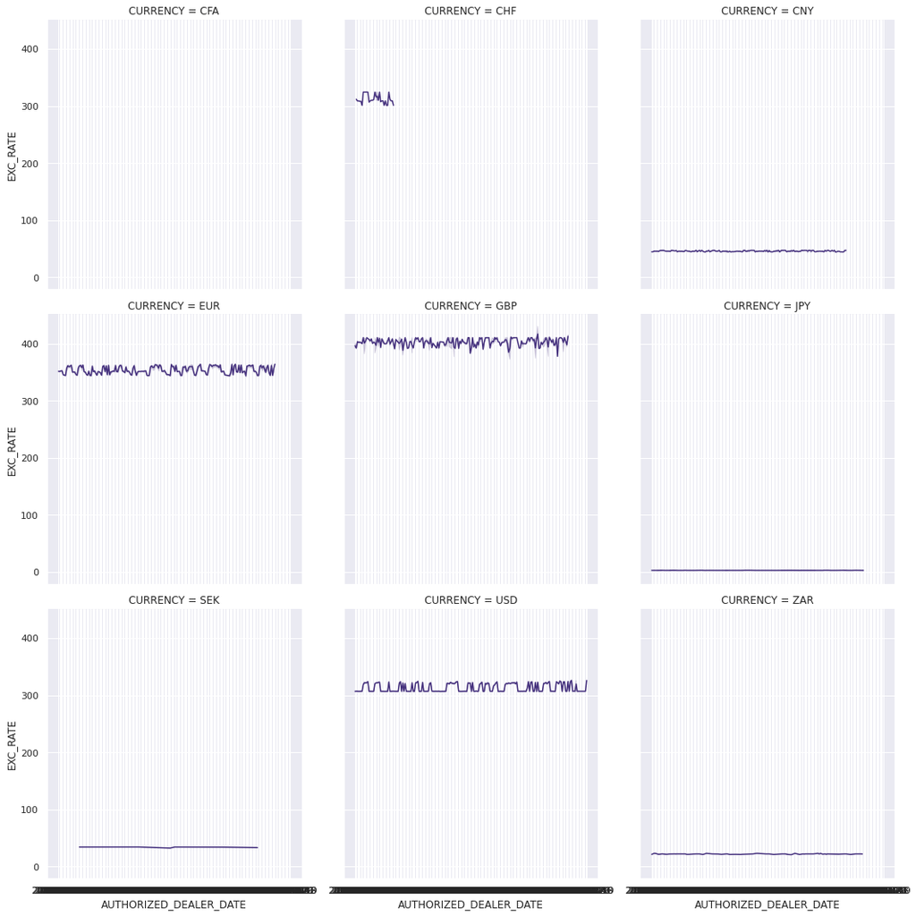

```python
plt.figure(figsize=(15, 12))
sns.set_palette('viridis')
sns.relplot(x='AUTHORIZED_DEALER_DATE', y='EXC_RATE', data=df,
kind='line', col='CURRENCY', col_wrap=3);
```

- The plot shows the rate of change in the exchange rate across time in 2019 in Nigeria base on different currency that was used in transaction

```python
df.APPLICANT_NAME.value_counts(10)
```

```
NESTLE NIG. PLC                               0.015425
BRITISH AMERICAN TOBACCO (NIGERIA) LIMITED    0.012918
DAG INDUSTRIES NIGERIA LIMITED.               0.009769
NIGERIAN BOTTLING COMPANY LIMITED             0.009126
EUROCHEMCO VENTURES LIMITED                   0.008853
                                                ...
LUIGRAD COMPANY NIG. LTD.                     0.000016
HABRO INVESTMENTS LIMITED                     0.000016
JULLYMAX INTERNATIONAL LIMITED                0.000016
ASONA INVESTMENTS NIGERIA LIMITED             0.000016
DE-OBABOB INVESTMENT LTD. CALABAR             0.000016
Name: APPLICANT_NAME, Length: 3373, dtype: float64
```

#### Were there any interesting or surprising interactions between features?

- Yes, after the x and y scale was logged the relationship between and the features were clearer